# Employee Attrition Prediction with R Accelerator

### Step 4 Model building

- Select algorithm for model creation.
- Tune model parameters.

```r
# initialize training control.

tc <- trainControl(method="repeatedcv",
                   number=3,
                   repeats=3,
                   search="grid",
                   classProbs=TRUE,
                   savePredictions="final",
                   summaryFunction=twoClassSummary)
```

### Step 4 Model building (Cont'd)

Let's try several machine learning algorithms.

- Support vector machine.

```r
# SVM model.

time_svm <- system.time(
  model_svm <- train(Attrition ~ .,
                     df1_train,
                     method="svmRadial",
                     trainControl=tc)
)
```

### Step 4 Model building (Cont'd)

- Random forest.

```r
# random forest model

time_rf <- system.time(
  model_rf <- train(Attrition ~ .,
                     df1_train,
                     method="rf",
                     trainControl=tc)
)
```

### Step 4 Model building (Cont'd)

- Extreme gradient boosting (XGBoost).

```r
# xgboost model.

time_xgb <- system.time(
  model_xgb <- train(Attrition ~ .,
                     df1_train,
                     method="xgbLinear",
                     trainControl=tc)
)
```

### Step 4 Model building (Cont'd)

An ensemble may be better?

- Ensemble of models.
- Ensemble methods - bagging, boosting, and stacking.

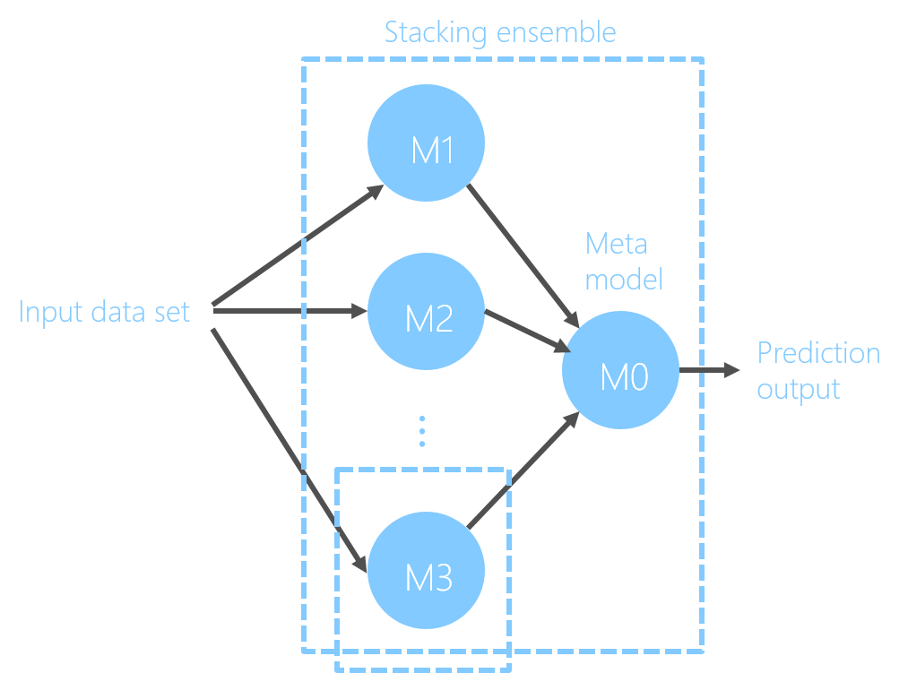

```r
# ensemble of the three models.

time_ensemble <- system.time(
  model_list <- caretList(Attrition ~ .,
                          data=df1_train,
                          trControl=tc,
                          methodList=c("svmRadial", "rf", "xgbLinear"))
)
```

```r
# stack of models. Use glm for meta model.

model_stack <- caretStack(
  model_list,
  metric="ROC",
  method="glm",
  trControl=trainControl(
    method="boot",
    number=10,
    savePredictions="final",
    classProbs=TRUE,
    summaryFunction=twoClassSummary
  )
)
```

### Step 5 Model evaluating

- Confusion matrix.
- Performance measure.

```r
predictions <-lapply(models,
                     predict,
                     newdata=select(df1_test, -Attrition))
```

```r
# confusion matrix evaluation results.

cm_metrics <- lapply(predictions,
                     confusionMatrix,
                     reference=df1_test$Attrition,
                     positive="Yes")
```

### Step 5 Model evaluating (Cont'd)

- Comparison of different models in terms of accuracy, recall, precision, and elapsed time.

```
         Models Accuracy Recall Precision Elapsed
1       SVM RBF     0.86   0.76      0.55   27.69
2 Random Forest     0.92   0.80      0.71  220.19
3       Xgboost     0.92   0.82      0.73  290.05
4      Stacking     0.92   0.85      0.71   84.36
```

- Analysis
  - Diversity of model affects ensemble performance.
  - Data size also impacts.

### Step 6 Sentiment analysis - a glimpse of data

```r
# getting the data.

head(df2$Feedback, 5)
```

```
[1] "People are willing to share knowledge which is not the norm in this industry This is the first place I have worked where the people are great about that Also I get to work on cool projects that no one else in the world works on"
[2] "To repeat what I wrote before the people I work for and work with here are very smart and confident people"
[3] "The variety of different projects and the speed of completion I am truly very satisfied  pleased there is an endless list of pros"
[4] "As youve probably heard Google has great benefits insurance and flexible hours If you want to you can work from home"
[5] "Great insurance benefits free food equipment is available whenever you want it to be and there is always whatever you need monitor etc"
```

### Step 7 Sentiment analysis - feature extraction

- General methods
  - Initial transformation
    - Removal of unnecessary elements (stopwords, numbers, punctuations, etc.).
      - Stopwords: yes, no, you, I, etc.
    - Translation or sentence/word alignment.
    - Part-Of-Speech tagging.
  - Bag-of-words model
    - n-Grams.
    - Term frequency (TF) or Term frequency inverse-document frequency (TF-IDF).
  - Model creation

### Step 7 Sentiment analysis - feature extraction (Cont'd)

```r
# create a corpus based upon the text data.

corp_text <- Corpus(VectorSource(df2$Feedback))
```

```r
# transformation on the corpus.

corp_text %<>%
  tm_map(removeNumbers) %>%
  tm_map(content_transformer(tolower)) %>%
  tm_map(removeWords, stopwords("english")) %>%
  tm_map(removePunctuation) %>%
  tm_map(stripWhitespace)
```

```r
dtm_txt_tf <-
  DocumentTermMatrix(corp_text, control=list(wordLengths=c(1, Inf), weighting=weightTf))
```

```r
# remove sparse terms.

dtm_txt <-
  removeSparseTerms(dtm_txt_tf, 0.99)
```

### Step 7 Sentiment analysis - feature extraction (Cont'd)

- Convert corpus to term frequency matrix.

```r
dtm_txt_sample <- removeSparseTerms(dtm_txt_tf, 0.85)
inspect(dtm_txt_sample[1:10, ])
```

```
<<DocumentTermMatrix (documents: 10, terms: 6)>>
Non-/sparse entries: 19/41
Sparsity           : 68%
Maximal term length: 7
Weighting          : term frequency (tf)

    Terms
Docs company google great people smart work
  1        0      0     1      2     0    1
  2        0      0     0      2     1    2
  3        0      0     0      0     0    0
  4        0      1     1      0     0    1
  5        0      0     1      0     0    0
  6        0      0     0      2     1    1
  7        0      0     0      0     0    0
  8        0      0     1      1     0    3
  9        0      0     1      0     0    0
  10       0      0     0      1     0    1
```

### Step 8 Sentiment analysis - model creation and validation

- Create and validate a classification model.

```r
# form the data set

df_txt %<>% cbind(Attrition=df2$Attrition)
```

```r
# split data set into training and testing set.

train_index <-
  createDataPartition(df_txt$Attrition,
                      times=1,
                      p=.7) %>%
  unlist()

df_txt_train <- df_txt[train_index, ]
df_txt_test <- df_txt[-train_index, ]
```

### Step 8 Sentiment analysis - model creation and validation (Cont'd)

- SVM is used.

```r
# model building

model_sent <- train(Attrition ~ .,
                    df_txt_train,
                    method="svmRadial",
                    trainControl=tc)
```

```r
prediction <- predict(model_sent, newdata=select(df_txt_test, -Attrition))
```

### Step 8 Sentiment analysis - model creation and validation (Cont'd)

```
Confusion Matrix and Statistics

          Reference
Prediction No Yes
       No  87  13
       Yes  3  47

               Accuracy : 0.8933
                 95% CI : (0.8326, 0.9378)
    No Information Rate : 0.6
    P-Value [Acc > NIR] : 1.336e-15

                  Kappa : 0.7714
 Mcnemar's Test P-Value : 0.02445

            Sensitivity : 0.7833
            Specificity : 0.9667
         Pos Pred Value : 0.9400
         Neg Pred Value : 0.8700
             Prevalence : 0.4000
         Detection Rate : 0.3133
   Detection Prevalence : 0.3333
      Balanced Accuracy : 0.8750

       'Positive' Class : Yes
```

### Takeaways

- DS & ML combined with domain knowledge.
- Feature engineering takes majority of time.
- Model creation and validation.
- Sentiment analysis on text data.
- All resources available on Github! https://github.com/Microsoft/acceleratoRs/tree/master/EmployeeAttritionPrediction/Docs/FOSSAsiaMeetup

### References

1. Terence R. Michelle et al., “Why people stay: using job embeddedness to predict voluntary turnover”.
2. Bo Pang and Lillian Lee, “Opinion mining and sentiment analysis”.
3. Nitesh V. Chawla et al., “SMOTE: Synthetic Minority Over-sampling Technique”.

### Contact

Le Zhang

zhle@microsoft.com